# papers slides

## Campus Recruitment

### Academic and Employability Factors influencing placement

（其实就是用一些变量预测一个人能不能找到工作）

[figure not shown]

### Hello

My name is Ben Roshan D, doing MBA in Business Analytics at Jain University Bangalore . We have practical sessions in Python,R as subjects. Faculties provide us with such data sets to work on with it, So here is one of the data set which our class worked on

### What is in it?

This data set consists of Placement data of students in a XYZ campus. It includes secondary and higher secondary school percentage and specialization. It also includes degree specialization, type and Work experience and salary offers to the placed students

（ps：内容搬运自Kaggle）

### 用来做预测的变量

| 变量名 | 说明 |
| --- | --- |
| gender | 性别 |
| ssc_p | 初中课程平均分 |
| ssc_b | 初中教育委员会级别 |
| hsc_p | 高中课程平均分 |
| hsc_b | 高中教育委员会级别 |
| hsc_s | 在高中选择的专业 |
| degree_p | 本科课程平均分 |
| degree_t | 本科专业 |
| workex | 是否有工作经验 |
| etest_p | 就业能力测试分数 |
| specialisation | MBA硕士研究方向 |
| mba_p | MBA硕士课程平均分数 |

### 先看一下数据长什么样

```python
data=pd.read_csv(r'C:\Users\freshman314\Desktop\data.csv')
data=data.iloc[:,1:]
data
```

|  | gender | ssc_p | ssc_b | hsc_p | hsc_b | hsc_s | degree_p | degree_t | workex | etest_p | specialisation | mba_p | status | salary |
| --- | --- | --- | --- | --- | --- | --- | --- | --- | --- | --- | --- | --- | --- | --- |
| 0 | M | 67.00 | Others | 91.00 | Others | Commerce | 58.00 | Sci&Tech | No | 55.0 | Mkt&HR | 58.80 | Placed | 270000.0 |
| 1 | M | 79.33 | Central | 78.33 | Others | Science | 77.48 | Sci&Tech | Yes | 86.5 | Mkt&Fin | 66.28 | Placed | 200000.0 |
| 2 | M | 65.00 | Central | 68.00 | Central | Arts | 64.00 | Comm&Mgmt | No | 75.0 | Mkt&Fin | 57.80 | Placed | 250000.0 |
| 3 | M | 56.00 | Central | 52.00 | Central | Science | 52.00 | Sci&Tech | No | 66.0 | Mkt&HR | 59.43 | Not Placed | NaN |
| 4 | M | 85.80 | Central | 73.60 | Central | Commerce | 73.30 | Comm&Mgmt | No | 96.8 | Mkt&Fin | 55.50 | Placed | 425000.0 |
| ... | ... | ... | ... | ... | ... | ... | ... | ... | ... | ... | ... | ... | ... | ... |
| 210 | M | 80.60 | Others | 82.00 | Others | Commerce | 77.60 | Comm&Mgmt | No | 91.0 | Mkt&Fin | 74.49 | Placed | 400000.0 |
| 211 | M | 58.00 | Others | 60.00 | Others | Science | 72.00 | Sci&Tech | No | 74.0 | Mkt&Fin | 53.62 | Placed | 275000.0 |
| 212 | M | 67.00 | Others | 67.00 | Others | Commerce | 73.00 | Comm&Mgmt | Yes | 59.0 | Mkt&Fin | 69.72 | Placed | 295000.0 |
| 213 | F | 74.00 | Others | 66.00 | Others | Commerce | 58.00 | Comm&Mgmt | No | 70.0 | Mkt&HR | 60.23 | Placed | 204000.0 |
| 214 | M | 62.00 | Central | 58.00 | Others | Science | 53.00 | Comm&Mgmt | No | 89.0 | Mkt&HR | 60.22 | Not Placed | NaN |

215 rows × 14 columns

### 将salary列的缺失值填补为0

```python
data['salary']=data['salary'].fillna(0)
data
```

|  | gender | ssc_p | ssc_b | hsc_p | hsc_b | hsc_s | degree_p | degree_t | workex | etest_p | specialisation | mba_p | status | salary |
| --- | --- | --- | --- | --- | --- | --- | --- | --- | --- | --- | --- | --- | --- | --- |
| 0 | M | 67.00 | Others | 91.00 | Others | Commerce | 58.00 | Sci&Tech | No | 55.0 | Mkt&HR | 58.80 | Placed | 270000.0 |
| 1 | M | 79.33 | Central | 78.33 | Others | Science | 77.48 | Sci&Tech | Yes | 86.5 | Mkt&Fin | 66.28 | Placed | 200000.0 |
| 2 | M | 65.00 | Central | 68.00 | Central | Arts | 64.00 | Comm&Mgmt | No | 75.0 | Mkt&Fin | 57.80 | Placed | 250000.0 |
| 3 | M | 56.00 | Central | 52.00 | Central | Science | 52.00 | Sci&Tech | No | 66.0 | Mkt&HR | 59.43 | Not Placed | 0.0 |
| 4 | M | 85.80 | Central | 73.60 | Central | Commerce | 73.30 | Comm&Mgmt | No | 96.8 | Mkt&Fin | 55.50 | Placed | 425000.0 |
| ... | ... | ... | ... | ... | ... | ... | ... | ... | ... | ... | ... | ... | ... | ... |
| 210 | M | 80.60 | Others | 82.00 | Others | Commerce | 77.60 | Comm&Mgmt | No | 91.0 | Mkt&Fin | 74.49 | Placed | 400000.0 |
| 211 | M | 58.00 | Others | 60.00 | Others | Science | 72.00 | Sci&Tech | No | 74.0 | Mkt&Fin | 53.62 | Placed | 275000.0 |
| 212 | M | 67.00 | Others | 67.00 | Others | Commerce | 73.00 | Comm&Mgmt | Yes | 59.0 | Mkt&Fin | 69.72 | Placed | 295000.0 |
| 213 | F | 74.00 | Others | 66.00 | Others | Commerce | 58.00 | Comm&Mgmt | No | 70.0 | Mkt&HR | 60.23 | Placed | 204000.0 |
| 214 | M | 62.00 | Central | 58.00 | Others | Science | 53.00 | Comm&Mgmt | No | 89.0 | Mkt&HR | 60.22 | Not Placed | 0.0 |

215 rows × 14 columns

### 很好，接下来让我们把数据画成图

```python
pp.ProfileReport(data)
```

[interactive chart not shown]

### 让我们看一下找到工作的和没找到工作的毕业生在各变量上的分布

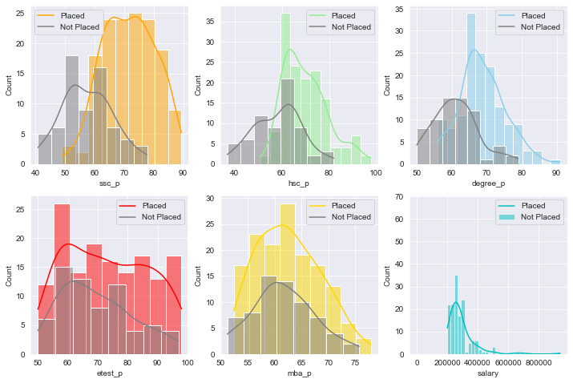

```python
color=["orange","lightgreen","skyblue","red","gold","c"]
plt.figure(figsize=(12, 8))
for c in numerical_list:
    plt.subplot(2, 3, i)
    dou_bar(c,color[i-1])
    i += 1
```

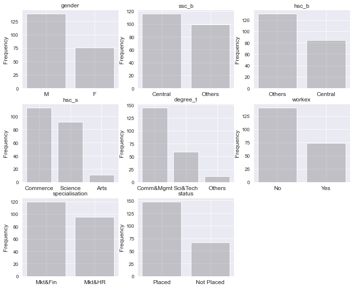

```python
i = 1
plt.figure(figsize=(12, 10))
sns.set_style('darkgrid')
for c in categorical_list:
    plt.subplot(3, 3, i)
    bar_plot(c,i)
    i += 1
```

### 散点图矩阵

[figure not shown]

### 对定性数据进行独热编码处理

```python
cat_cols=["gender","ssc_b","hsc_b","hsc_s","degree_t","workex","specialisation"]
data_dumcat=pd.get_dummies(data[cat_cols])
data_dumcat
```

|  | gender_F | gender_M | ssc_b_Central | ssc_b_Others | hsc_b_Central | hsc_b_Others | hsc_s_Arts | hsc_s_Commerce | hsc_s_Science | degree_t_Comm&Mgmt | degree_t_Others | degree_t_Sci&Tech | workex_No | workex_Yes | specialisation_Mkt&Fin | specialisation_Mkt&HR |
| --- | --- | --- | --- | --- | --- | --- | --- | --- | --- | --- | --- | --- | --- | --- | --- | --- |
| 0 | 0 | 1 | 0 | 1 | 0 | 1 | 0 | 1 | 0 | 0 | 0 | 1 | 1 | 0 | 0 | 1 |
| 1 | 0 | 1 | 1 | 0 | 0 | 1 | 0 | 0 | 1 | 0 | 0 | 1 | 0 | 1 | 1 | 0 |
| 2 | 0 | 1 | 1 | 0 | 1 | 0 | 1 | 0 | 0 | 1 | 0 | 0 | 1 | 0 | 1 | 0 |
| 3 | 0 | 1 | 1 | 0 | 1 | 0 | 0 | 0 | 1 | 0 | 0 | 1 | 1 | 0 | 0 | 1 |
| 4 | 0 | 1 | 1 | 0 | 1 | 0 | 0 | 1 | 0 | 1 | 0 | 0 | 1 | 0 | 1 | 0 |
| ... | ... | ... | ... | ... | ... | ... | ... | ... | ... | ... | ... | ... | ... | ... | ... | ... |
| 210 | 0 | 1 | 0 | 1 | 0 | 1 | 0 | 1 | 0 | 1 | 0 | 0 | 1 | 0 | 1 | 0 |
| 211 | 0 | 1 | 0 | 1 | 0 | 1 | 0 | 0 | 1 | 0 | 0 | 1 | 1 | 0 | 1 | 0 |
| 212 | 0 | 1 | 0 | 1 | 0 | 1 | 0 | 1 | 0 | 1 | 0 | 0 | 0 | 1 | 1 | 0 |
| 213 | 1 | 0 | 0 | 1 | 0 | 1 | 0 | 1 | 0 | 1 | 0 | 0 | 1 | 0 | 0 | 1 |
| 214 | 0 | 1 | 1 | 0 | 0 | 1 | 0 | 0 | 1 | 1 | 0 | 0 | 1 | 0 | 0 | 1 |

215 rows × 16 columns

### 对数值型数据进行标准化处理

标准差标准化，也叫z-score标准化:
$$ x =\frac{(x - u)}{\sigma} $$ 其中，$ \mu $ 是数据的均值, $ \sigma $ 是数据的标准差，当各个变量量纲存在差异时，可以使用这种处理方法。这种标准化处理后的数据符合标准正态分布

需要使用距离来度量相似性的分类、聚类算法，还有使用PCA进行降维的时候，Z-score标准化表现更好

```python
data_scaled
```

|  | ssc_p | hsc_p | degree_p | etest_p | mba_p |
| --- | --- | --- | --- | --- | --- |
| 0 | -0.028087 | 2.268812 | -1.140102 | -1.291091 | -0.597647 |
| 1 | 1.113369 | 1.103448 | 1.513267 | 1.087157 | 0.687620 |
| 2 | -0.213238 | 0.153313 | -0.322843 | 0.218908 | -0.769474 |
| 3 | -1.046417 | -1.318339 | -1.957362 | -0.460592 | -0.489396 |
| 4 | 1.712332 | 0.668391 | 0.943909 | 1.864806 | -1.164676 |
| ... | ... | ... | ... | ... | ... |
| 210 | 1.230940 | 1.441008 | 1.529612 | 1.426906 | 2.098321 |
| 211 | -0.861266 | -0.582513 | 0.766836 | 0.143408 | -1.487711 |
| 212 | -0.028087 | 0.061335 | 0.903046 | -0.989091 | 1.278706 |
| 213 | 0.619941 | -0.030644 | -1.140102 | -0.158592 | -0.351934 |
| 214 | -0.490964 | -0.766470 | -1.821152 | 1.275907 | -0.353652 |

215 rows × 5 columns

### 分割训练集和测试集

为了完成之后的交叉验证，将数据分为训练集和测试集，样本比为4：1

### PCA降维

将独热编码处理后的数据进行压缩，减少特征的冗杂程度，让构造出来的模型更加简洁

```python
from sklearn.decomposition import PCA
pca=PCA(n_components='mle').fit(x_train)
x_trainPCA=pca.transform(x_train)
x_testPCA=pca.transform(x_test)
print('降维前的训练集共有{}列'.format(x_train.shape[1]))
print('降维前的训练集共有{}列'.format(x_trainPCA.shape[1]))
```

```
降维前的训练集共有21列
降维前的训练集共有14列
```

### 使用KMeans算法探索类别数量

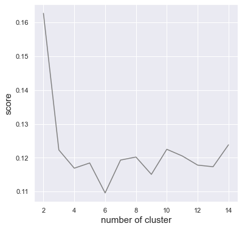

```python
plt.figure(figsize=(6,6))
plt.plot(range(2,15),silhouettteScore,linestyle='-',color='grey')
plt.xlabel('number of cluster',fontsize=15)
plt.ylabel('score',fontsize=15)
plt.show()
```

### 使用FMI评分确定类别数

```python
from sklearn.metrics import fowlkes_mallows_score
for i in range(2,7):
    kmeans=KMeans(n_clusters=i,random_state=123).fit(x_trainPCA)
    score1=fowlkes_mallows_score(y_train,kmeans.labels_)
    print('聚{}类FMI评价分数为{}'.format(i,score1))
```

```
聚2类FMI评价分数为0.5863445247190077
聚3类FMI评价分数为0.5592268611731858
聚4类FMI评价分数为0.4743290787407349
聚5类FMI评价分数为0.4106681865638894
聚6类FMI评价分数为0.414749812123822
```

### 种一片随机森林🌵🌵🌵

理论上，随着随机森林中的决策树数量的增加，模型的准确率也会逐渐上升，但最终还是会趋于一个上限

### 使用随机森林——训练集与验证集

```
训练集的最高准确率为0.88，是在种78棵决策树时得到的
```

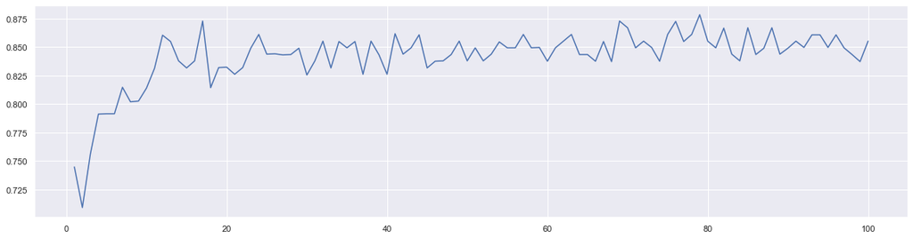

```python
from sklearn.ensemble import RandomForestClassifier
superpa = []
for i in range(100):
    rfc = RandomForestClassifier(n_estimators=i+1,n_jobs=-1)
    rfc_s = cross_val_score(rfc,x_trainPCA,y_train,cv=10).mean()
    superpa.append(rfc_s)
print('训练集的最高准确率为{:.2f}，是在种{}棵决策树时得到的'.format(max(superpa),superpa.index(max(superpa))))
plt.figure(figsize=[20,5])
plt.plot(range(1,101),superpa)
plt.show()
```

### 让我们看一下模型在测试集上的表现

```python
rfc = RandomForestClassifier(n_estimators=78,n_jobs=-1).fit(x_trainPCA,y_train)
print('测试集的准确率为{:.2f}'.format(rfc.score(x_testPCA,y_test)))
y_predict_rfc=rfc.predict(x_testPCA)
```

```
测试集的准确率为0.84
```

### 在模型中，哪个变量更重要？

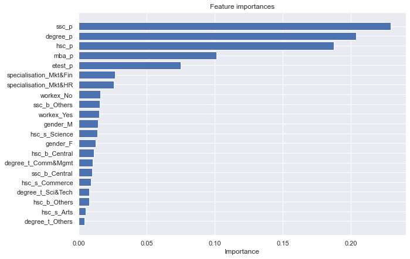

```python
from sklearn.ensemble import RandomForestClassifier
rfc = RandomForestClassifier().fit(x_train,y_train)
features_list = x_train.columns.values
feature_importance = rfc.feature_importances_
sorted_idx = np.argsort(feature_importance)
plt.figure(figsize=(10,7))
plt.barh(range(len(sorted_idx)), feature_importance[sorted_idx], align='center')
plt.yticks(range(len(sorted_idx)), features_list[sorted_idx])
plt.xlabel('Importance')
plt.title('Feature importances')
plt.draw()
plt.show()
```

### 使用SVM分类器——训练集与验证集

```python
from sklearn.svm import SVC
svm_data=SVC().fit(x_trainPCA,y_train)
from sklearn.model_selection import cross_val_score
accuracies = cross_val_score(estimator = svm_data, X = x_train, y = y_train, cv = 10)
print("训练集准确率为: {:.2f} %".format(accuracies.mean()*100))
print("标准差为: {:.2f} %".format(accuracies.std()*100))
```

```
训练集准确率为: 86.08 %
标准差为: 6.40 %
```

### 使用SVM分类器——测试集

```python
from sklearn.svm import SVC
svm_data=SVC().fit(x_trainPCA,y_train)
print('测试集的准确率为{:.2f}'.format(svm_data.score(x_testPCA,y_test)))
```

```
测试集的准确率为0.79
```

### 使用SVM分类器——调参

```
训练的最高准确率为1.00,在gamma=5.96时取到。
测试集的最高准确率为0.81,在gamma=0.02时取到。
```

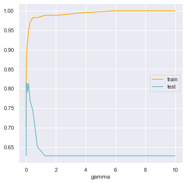

```python
print('训练的最高准确率为{:.2f},在gamma={:.2f}时取到。'.format(max(score), gamma_range[score.index(max(score))]))
print('测试集的最高准确率为{:.2f},在gamma={:.2f}时取到。'.format(max(score_test), gamma_range[score_test.index(max(score_test))]))
plt.figure(figsize=(6,6))
plt.plot(gamma_range,score,color='orange')
plt.xlabel('gamma')
plt.plot(gamma_range,score_test,color='c')
plt.legend(['train','test'])
plt.show()
```

### ROC曲线与AUC值

曲线距离左上角越近，证明分类器效果越好。而AUC值为ROC曲线所覆盖的区域面积，显然，AUC越大，分类器分类效果越好。

### 绘制ROC曲线

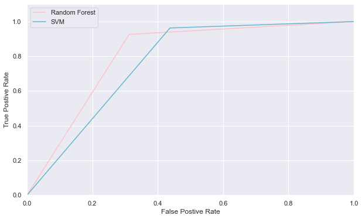

```python
from sklearn.metrics import roc_curve
plt.figure(figsize=(10,6))
fpr1,tpr1,thresholds1=roc_curve(y_test_label,y_predict_label_rfc)
fpr2,tpr2,threshold2=roc_curve(y_test_label,y_predict_label_svm)
plt.xlim(0,1)
plt.ylim(0.0,1.1)
plt.xlabel("False Postive Rate")
plt.ylabel("True Postive Rate")
plt.plot(fpr1,tpr1,linestyle='-',color='pink',)
plt.plot(fpr2,tpr2,linestyle='-',color='c')
plt.legend(['Random Forest','SVM'],)
plt.show()
```

### 计算AUC值

```python
from sklearn import metrics
print('随机森林的AUC值为{:.2f}。'.format(metrics.auc(fpr1, tpr1)))
print('SVM的AUC值为{:.2f}。'.format(metrics.auc(fpr2, tpr2)))
```

```
随机森林的AUC值为0.81。
SVM的AUC值为0.76。
```

### 完结，撒花🎉🎉

[figure not shown]